# Biostatistics 2 - Final Project

Ziwen Zhang

2023-04-13

# Question 1

### Load dataset and libraries

```r
mydata <- read.csv("https://stats.idre.ucla.edu/stat/data/binary.csv")
```

## (a)

1. Run a multiple linear regression to predict gpa use all covariates.

```r
# Fit a multiple linear regression
model <- lm(gpa ~ ., data = mydata)

# View the model summary
summary(model)
```

```
##
## Call:
## lm(formula = gpa ~ ., data = mydata)
##
## Residuals:
##      Min       1Q   Median       3Q      Max
## -1.13556 -0.21725 -0.00307  0.25397  0.77234
##
## Coefficients:
##              Estimate Std. Error t value Pr(>|t|)
## (Intercept) 2.6380148  0.1079298  24.442  < 2e-16 ***
## admit       0.0935915  0.0392765   2.383   0.0176 *
## gre         0.0012026  0.0001549   7.762 7.19e-14 ***
## rank        0.0062047  0.0191971   0.323   0.7467
## ---
## Signif. codes:  0 '***' 0.001 '**' 0.01 '*' 0.05 '.' 0.1 ' ' 1
##
## Residual standard error: 0.3502 on 396 degrees of freedom
## Multiple R-squared:  0.1598, Adjusted R-squared:  0.1534
## F-statistic: 25.11 on 3 and 396 DF,  p-value: 6.852e-15
```

```r
# Extract the coefficients for each variable
coef(model)
```

```
## (Intercept)       admit         gre        rank
## 2.638014826 0.093591537 0.001202571 0.006204686
```

## (b)

2. What is the interpretation of your regression coefficients?

**Answer:**

The intercept coefficient represents the expected gpa value when all other predictor variables are equal to zero. In this case, it is 2.638014826, which means that if a student had a GRE score of zero, a prestige rank of 0, and was not admitted, the expected GPA would be 2.638014826.

The coefficient for admit represents the expected change in gpa for a one-unit increase in the admit variable, holding all other variables constant. In this case, the coefficient is 0.093591537, which means that for a student from not being admitted to being admitted, the expected GPA would increase 0.093591537, holding other variables constant.

The coefficient for gre represents the expected change in gpa for a one-unit increase in the gre variable, holding all other variables constant. In this case, the coefficient is 0.001202571, which means that for every one point increase in the gre score, the expected gpa would increase 0.001202571, holding other variables constant.

The coefficient for rank represents the expected change in gpa for a one-unit increase in the rank variable, holding all other variables constant. In this case, the coefficient is 0.006204686, which means that for every one unit increase in the prestige rank (i.e., going from a less prestigious to a more prestigious undergraduate institution), the expected gpa would increases 0.006204686, holding other variables constant.

## (c)

3. Comment on the model fit from residual plots and coefficient of determination/AIC/BIC

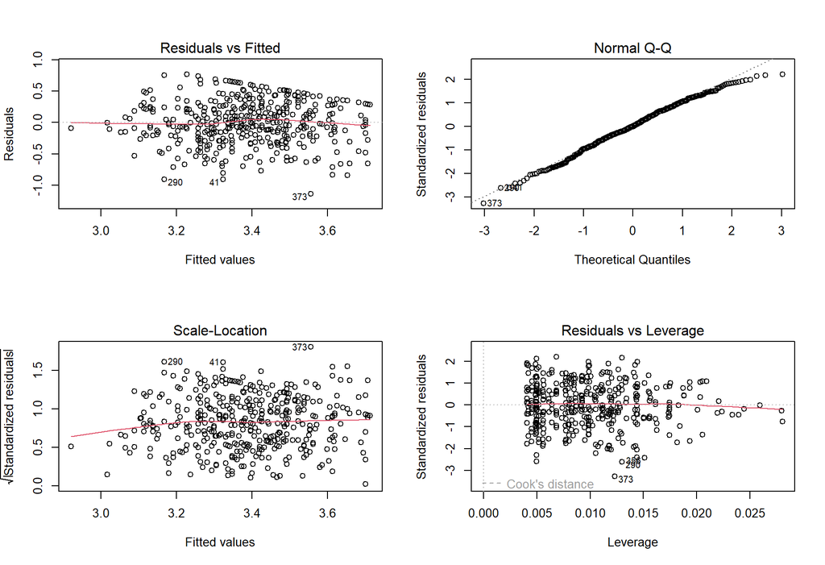

```r
# Generate residual plots
par(mfrow = c(2,2))
plot(model)
```

**Comments:**

The normal Q-Q plot can help us assess whether the residuals are normally distributed. Ideally, we want to see the points follow a diagonal line. In this case, the points appear to deviate from the line at the upper tails, suggesting that the residuals may not be perfectly normally distributed.

The residuals vs. leverage plot can help us identify influential observations or outliers. Ideally, we want to see a random scatter of points around the horizontal line at zero. In this case, there are a few observations with high leverage and large residuals, which suggests that they may be influential in the model.

```r
# View the model summary
summary(model)
```

```
##
## Call:
## lm(formula = gpa ~ ., data = mydata)
##
## Residuals:
##      Min       1Q   Median       3Q      Max
## -1.13556 -0.21725 -0.00307  0.25397  0.77234
##
## Coefficients:
##              Estimate Std. Error t value Pr(>|t|)
## (Intercept) 2.6380148  0.1079298  24.442  < 2e-16 ***
## admit       0.0935915  0.0392765   2.383   0.0176 *
## gre         0.0012026  0.0001549   7.762 7.19e-14 ***
## rank        0.0062047  0.0191971   0.323   0.7467
## ---
## Signif. codes:  0 '***' 0.001 '**' 0.01 '*' 0.05 '.' 0.1 ' ' 1
##
## Residual standard error: 0.3502 on 396 degrees of freedom
## Multiple R-squared:  0.1598, Adjusted R-squared:  0.1534
## F-statistic: 25.11 on 3 and 396 DF,  p-value: 6.852e-15
```

**Comments:**

The coefficient of determination (R^2) is a measure of how much of the variance in the response variable is explained by the predictor variables. In this case, the adjusted R-squared value for this model is 0.1534, which means that approximately 15.34% of the variance in gpa is explained by the predictor variables in the model. This result shows that the model is not good.

```r
# Calculate AIC and BIC
AIC(model)
```

```
## [1] 301.624
```

```r
BIC(model)
```

```
## [1] 321.5813
```

**Comments:**

The AIC and BIC are measures of model fit that take into account both the goodness of fit and the complexity of the model. In general, lower AIC and BIC values indicate better model fit. The AIC value for this model is 301.624, and the BIC value is 321.5813. This result shows that the model is relatively not good.

## (d)

4. For a new observation, admitted, GRE 700, rank 3, what is the predicted gpa? What are the confidence intervals for the predicted mean and the new observation separately?

```r
# Create new observation
newdata <- data.frame(admit = 1, gre = 700, rank = 3)

# Predict gpa for new observation
pred <- predict(model, newdata)

# View predicted gpa
paste("The predicted gpa is: ", round(pred, 3))
```

```
## [1] "The predicted gpa is:  3.592"
```

For a new observation, admitted, GRE 700, rank 3, the predicted gpa is 3.592.

```r
# Predict confidence intervals for mean and new observation
CI_mean <- predict(model, newdata, interval = "confidence")
CI_newobs <- predict(model, newdata, interval = "prediction")

# View confidence intervals
paste("The confidence intervals for the predicted mean is: ")
```

```
## [1] "The confidence intervals for the predicted mean is: "
```

```r
CI_mean
```

```
##       fit      lwr    upr
## 1 3.59202 3.517841 3.6662
```

```r
paste("The confidence intervals for the predicted mean is: ")
```

[output not shown]

```r
CI_newobs
```

```
##       fit      lwr      upr
## 1 3.59202 2.899643 4.284398
```

## (e)

5. If we drop rank as a predictor, compare this model with the previous one using F test?

```r
# Fit model without rank predictor
model_no_rank <- lm(gpa ~ admit + gre, data = mydata)

# Compare models using ANOVA F-test
anova(model_no_rank, model)
```

```
## Analysis of Variance Table
##
## Model 1: gpa ~ admit + gre
## Model 2: gpa ~ admit + gre + rank
##   Res.Df    RSS Df Sum of Sq      F Pr(>F)
## 1    397 48.565
## 2    396 48.553  1  0.012808 0.1045 0.7467
```

Since the p-value is 0.7467 > 0.05, there is no evidence to reject the null hypothesis that the reduced model performs differently from the full model. Therefore, we can conclude that the rank predictor does not significantly impact the model fit, and dropping it would not result in a different model.

## (f)

6. Consider the model with an interaction term of admission and rank. What is the interpretation of your regression model now?

```r
# fit the model with an interaction
model_interact <- lm(gpa ~ admit + gre + rank + admit * rank, data = mydata)

# View the model
summary(model_interact)
```

```
##
## Call:
## lm(formula = gpa ~ admit + gre + rank + admit * rank, data = mydata)
##
## Residuals:
##      Min       1Q   Median       3Q      Max
## -1.14768 -0.21742  0.00112  0.25403  0.77549
##
## Coefficients:
##               Estimate Std. Error t value Pr(>|t|)
## (Intercept)  2.6249870  0.1135060  23.126  < 2e-16 ***
## admit        0.1291334  0.1027002   1.257    0.209
## gre          0.0012028  0.0001551   7.755 7.59e-14 ***
## rank         0.0110937  0.0232304   0.478    0.633
## admit:rank  -0.0154208  0.0411641  -0.375    0.708
## ---
## Signif. codes:  0 '***' 0.001 '**' 0.01 '*' 0.05 '.' 0.1 ' ' 1
##
## Residual standard error: 0.3505 on 395 degrees of freedom
## Multiple R-squared:  0.1601, Adjusted R-squared:  0.1516
## F-statistic: 18.82 on 4 and 395 DF,  p-value: 3.529e-14
```

**Interpretation:**

The intercept coefficient represents the expected gpa value when all other predictor variables are equal to zero. In this case, it is 2.6249870, which means that if a student had a GRE score of zero, a prestige rank of 0, and was not admitted, the expected GPA would be 2.6249870.

The coefficient for admit represents the expected change in gpa for a one-unit increase in the admit variable, holding all other variables constant. In this case, the coefficient is 0.1291334, which means that for a student from not being admitted to being admitted, the expected GPA would increase 0.1291334, holding other variables constant. However, the large p-value (0.209) indicates this variable is not significantly impact for predicting gpa.

The coefficient for gre represents the expected change in gpa for a one-unit increase in the gre variable, holding all other variables constant. In this case, the coefficient is 0.0012028, which means that for every one point increase in the gre score, the expected gpa would increase 0.0012028, holding other variables constant.

# Question 2

### load library

```r
library(ResourceSelection)
```

```
## ResourceSelection 0.3-5   2019-07-22
```

```r
library(car)
library(pROC)
```

## (a)

1. Run a logistic regression to predict the admission use all covariates. What is the interpretation of your regression coefficients?

```r
# Fit a logistic regression model
model_glm <- glm(admit ~ gre + gpa + rank, data = mydata, family = binomial())

# View the model summary
summary(model_glm)
```

```
##
## Call:
## glm(formula = admit ~ gre + gpa + rank, family = binomial(),
##     data = mydata)
##
## Deviance Residuals:
##     Min       1Q   Median       3Q      Max
## -1.5802  -0.8848  -0.6382   1.1575   2.1732
##
## Coefficients:
##              Estimate Std. Error z value Pr(>|z|)
## (Intercept) -3.449548   1.132846  -3.045  0.00233 **
## gre          0.002294   0.001092   2.101  0.03564 *
## gpa          0.777014   0.327484   2.373  0.01766 *
## rank        -0.560031   0.127137  -4.405 1.06e-05 ***
## ---
## Signif. codes:  0 '***' 0.001 '**' 0.01 '*' 0.05 '.' 0.1 ' ' 1
##
## (Dispersion parameter for binomial family taken to be 1)
##
##     Null deviance: 499.98  on 399  degrees of freedom
## Residual deviance: 459.44  on 396  degrees of freedom
## AIC: 467.44
##
## Number of Fisher Scoring iterations: 4
```

```r
# Extract the coefficients for each variable
coef(model_glm)
```

```
## (Intercept)         gre         gpa        rank
## -3.44954840  0.00229396  0.77701357 -0.56003139
```

**Interpretation:**

The estimated coefficient of intercept is -3.449548, which means the log odds for being admitted for a student when all predictors are equal to zero is -3.449548.

The estimated coefficient for the predictor variables (including gre, gpa and rank) represent the change in the log-odds of admission for a one-unit increase in each predictor variable, holding all other variables constant.

## (b)

2. Compute residuals and conduct model diagnosis

```r
# Compute residuals
residuals <- resid(model_glm, type = "deviance")
head(residuals)
```

```
##          1          2          3          4          5          6
## -0.6483348  1.5141953  0.8143038  1.9514866 -0.4540705  1.3936053
```

```r
# Goodness-of-fit test
hoslem.test(mydata$admit, fitted(model_glm), g=10)
```

```
##
##  Hosmer and Lemeshow goodness of fit (GOF) test
##
## data:  mydata$admit, fitted(model_glm)
## X-squared = 3.2185, df = 8, p-value = 0.9199
```

since the p-value is 0.9199 > 0.05, there is no evidence to reject the null hypothesis that the observed frequencies of the outcome variable within each group are not significantly different from the expected frequencies based on the model’s predictions. Thus, this model is relatively good.

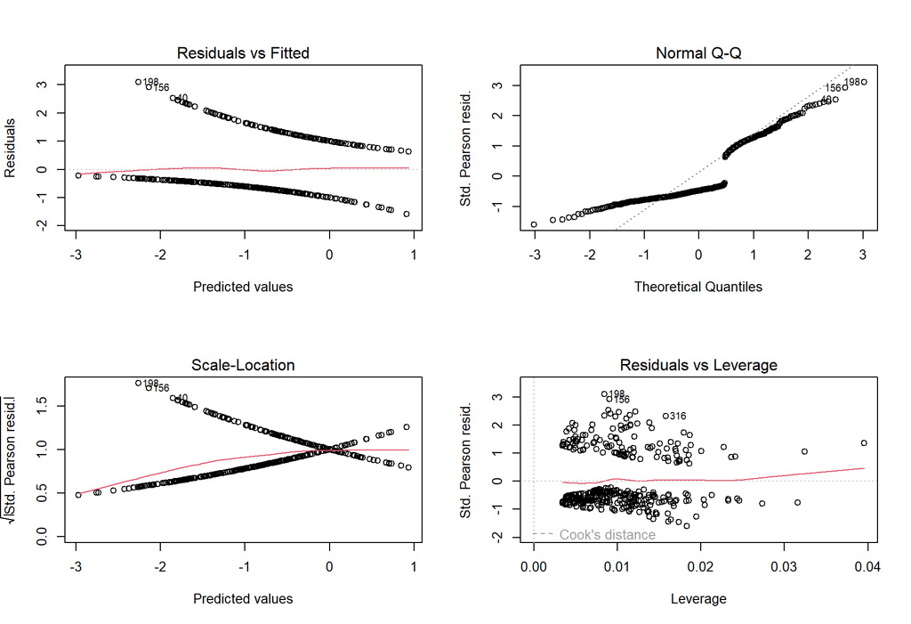

```r
# Generate residual plots
par(mfrow = c(2,2))
plot(model_glm)
```

```r
# vif test for colinearity
vif(model_glm)
```

```
##      gre      gpa     rank
## 1.135657 1.134708 1.004034
```

From the VIF score, we can see that there is no obvious colinearity among the predictors.

## (c)

3. Plot a ROC curve to evaluate your model prediction, calculate the area under the curve

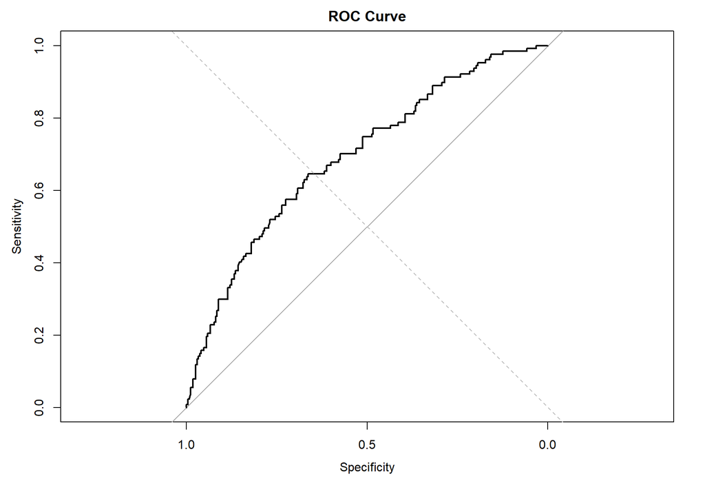

```r
# Get predicted probabilities
probs <- predict(model_glm, type = "response")

# Plot ROC curve
roc <- roc(mydata$admit, probs)
plot(roc, main="ROC Curve")
# Add reference line
abline(0,1,col ="gray",lty = 2)
```

```r
# Calculate AUC
auc(roc)
```

```
## Area under the curve: 0.6921
```

**Comment:**

The Area under the Curve is 0.6921, which indicates a relatively acceptable prediction.

## (d)

4. Remove rank as a predictor and compare two models using 1. AIC 2. Analysis of deviance

```r
# Fit model with rank removed
model_reduced <- glm(admit ~ gre + gpa, data = mydata, family = "binomial")

# Compare AICs
AIC(model_glm)
```

```
## [1] 467.4418
```

```r
AIC(model_reduced)
```

```
## [1] 486.344
```

```r
# Perform analysis of deviance
anova(model_glm, model_reduced, test = "Chi")
```

```
## Analysis of Deviance Table
##
## Model 1: admit ~ gre + gpa + rank
## Model 2: admit ~ gre + gpa
##   Resid. Df Resid. Dev Df Deviance  Pr(>Chi)
## 1       396     459.44
## 2       397     480.34 -1  -20.902 4.833e-06 ***
## ---
## Signif. codes:  0 '***' 0.001 '**' 0.01 '*' 0.05 '.' 0.1 ' ' 1
```

**Comment:**

From the analysis of deviance table, we can see that p-value is smaller than the significance level, indicating that there is a significant difference between the performances of full and reduced models.

AIC for full model is 467.4418 and AIC for reduced model is 486.344. This result shows that the full model with rank as a predictor is a superior model.

# Question 3

### load library and dataset

```r
library(KMsurv)
library(survival)
data(psych)
```

## (a)

Generate lifetime (only need to show the head) and km curve

```r
# Create a survival object (lifetime)
surv_obj <- with(psych, Surv(psych$time, psych$death))

# Compute the life table
life_table <- survfit(surv_obj ~ 1, conf.type = "none")

# Print the life table
print(life_table)
```

```
## Call: survfit(formula = surv_obj ~ 1, conf.type = "none")
##
##       n events median
## [1,] 26     14     35
```

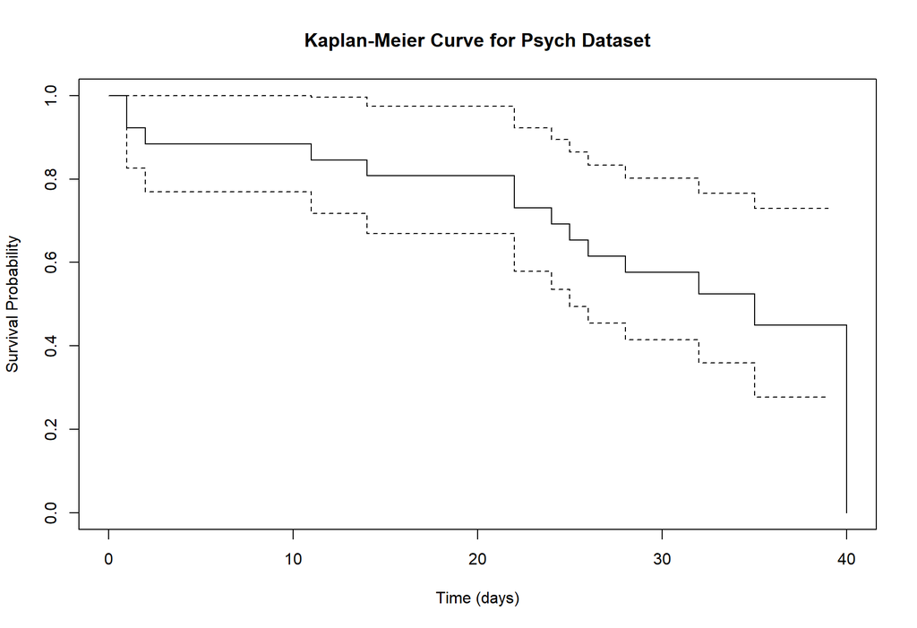

```r
# Generate a Kaplan-Meier curve
km_fit <- survfit(surv_obj ~ 1)

# Plot the Kaplan-Meier curve
plot(km_fit, xlab = "Time (days)", ylab = "Survival Probability", main = "Kaplan-Meier Curve for Psych Dataset")
```

## (b)

2. plot km surv by sex, use logrank test to compare two groups

[figure not shown]

```r
# Create separate survival objects for males and females
surv_male <- surv_obj[psych$sex == 1]
surv_female <- surv_obj[psych$sex == 2]

# Generate Kaplan-Meier curves for males and females
km_male <- survfit(surv_male ~ 1, conf.type = "none")
km_female <- survfit(surv_female ~ 1, conf.type = "none")

# Plot the Kaplan-Meier curves by sex
plot(km_male, col = "blue", xlab = "Time (days)", ylab = "Survival Probability", main = "KM Curves by Sex")
lines(km_female, col = "red")
```

```r
# Perform the log-rank test
logrank_test <- survdiff(surv_obj ~ psych$sex)
print(logrank_test)
```

```
## Call:
## survdiff(formula = surv_obj ~ psych$sex)
##
##              N Observed Expected (O-E)^2/E (O-E)^2/V
## psych$sex=1 11        4     6.24     0.807      1.61
## psych$sex=2 15       10     7.76     0.650      1.61
##
##  Chisq= 1.6  on 1 degrees of freedom, p= 0.2
```

From the result of the log-rank test, the p-value is 0.2 > 0.05, which indicates that there is no evidence to reject the null hypothesis and thus there is not a significant difference in survival between males and females. The KM curves show that males have a higher probability of survival than females.

## (c)

3. Run a parametric regression model with sex and age as predictors

```r
# Fit a Weibull regression model with sex and age as predictors
weibull_model <- survreg(surv_obj ~ psych$sex + psych$age, dist = "weibull")

# Print the model summary
summary(weibull_model)
```

```
##
## Call:
## survreg(formula = surv_obj ~ psych$sex + psych$age, dist = "weibull")
##               Value Std. Error     z       p
## (Intercept)  7.5726     1.0242  7.39 1.4e-13
## psych$sex    0.1278     0.3955  0.32   0.747
## psych$age   -0.1146     0.0275 -4.16 3.1e-05
## Log(scale)  -0.5478     0.2219 -2.47   0.014
##
## Scale= 0.578
##
## Weibull distribution
## Loglik(model)= -57.2   Loglik(intercept only)= -68.4
##  Chisq= 22.39 on 2 degrees of freedom, p= 1.4e-05
## Number of Newton-Raphson Iterations: 6
## n= 26
```

## (d)

4. Run a Cox model with both predictors. What is the interpretation of your regression coefficients? Comment on the model fit.

```r
# Fit a Cox proportional hazards model with sex and age as predictors
cox_model <- coxph(surv_obj ~ psych$sex + psych$age, data = psych)

# Print the model summary
summary(cox_model)
```

```
## Call:
## coxph(formula = surv_obj ~ psych$sex + psych$age, data = psych)
##
##   n= 26, number of events= 14
##
##               coef exp(coef) se(coef)      z Pr(>|z|)
## psych$sex -0.52374   0.59230  0.73753 -0.710  0.47762
## psych$age  0.20753   1.23063  0.05828  3.561  0.00037 ***
## ---
## Signif. codes:  0 '***' 0.001 '**' 0.01 '*' 0.05 '.' 0.1 ' ' 1
##
##           exp(coef) exp(-coef) lower .95 upper .95
## psych$sex    0.5923     1.6883    0.1396     2.514
## psych$age    1.2306     0.8126    1.0978     1.380
##
## Concordance= 0.816  (se = 0.081 )
## Likelihood ratio test= 20.91  on 2 df,   p=3e-05
## Wald test            = 14.3  on 2 df,   p=8e-04
## Score (logrank) test = 21.27  on 2 df,   p=2e-05
```

**Interpretation:**

The coefficient for age is 0.20753, which means that for each one-unit increase in age, the hazard ratio increases by exp(coef) = 1.2306, after controlling for sex. This means that older age is associated with a slightly higher hazard of failure, after controlling for sex.

However, the output shows that age is a significant predictors of survival whereas sex is not significant according to p-values.

## (e)

5. remove sex as a predictor, compare with the previous Cox model using analysis of deviance

```r
# Fit Cox model with age only
cox_reduced <- coxph(Surv(time, death) ~ psych$age, data = psych)

# Perform analysis of deviance
dev_reduced <- cox_reduced$loglik[2]
dev_full <- summary(cox_model)$loglik[2]
D <- 2*(dev_full - dev_reduced)
p_value <- 1 - pchisq(D, df = 1)

paste("Deviance of the full Cox model is: ", round(dev_full,3))
```

```
## [1] "Deviance of the full Cox model is:  -27.251"
```

```r
paste("Deviance of the reduced Cox model is: ", round(dev_reduced,3))
```

```
## [1] "Deviance of the reduced Cox model is:  -27.5"
```

```r
paste("Difference of Deviance is: ", round(D, 3))
```

```
## [1] "Difference of Deviance is:  0.498"
```

```r
paste ("P-value is: ", round(p_value, 3))
```

```
## [1] "P-value is:  0.48"
```

## (f)

6. run a stratified Cox model with sex as stratification variable

```r
# Fit stratified Cox model
cox_strat <- coxph(Surv(time, death) ~ psych$age + strata(psych$sex), data = psych)

# Print summary of the model
summary(cox_strat)
```

```
## Call:
## coxph(formula = Surv(time, death) ~ psych$age + strata(psych$sex),
##     data = psych)
##
##   n= 26, number of events= 14
##
##              coef exp(coef) se(coef)     z Pr(>|z|)
## psych$age 0.17869   1.19565  0.05588 3.198  0.00139 **
## ---
## Signif. codes:  0 '***' 0.001 '**' 0.01 '*' 0.05 '.' 0.1 ' ' 1
##
##           exp(coef) exp(-coef) lower .95 upper .95
## psych$age     1.196     0.8364     1.072     1.334
##
## Concordance= 0.819  (se = 0.087 )
## Likelihood ratio test= 15.19  on 1 df,   p=1e-04
## Wald test            = 10.22  on 1 df,   p=0.001
## Score (logrank) test = 14.33  on 1 df,   p=2e-04
```